# EDA assignment 7

Motoki Sugino

11/9/2016

### 1.Find a two-way table that you are interested in with at least 4 rows and 4 columns. Analyze the table using both additive AND multiplicative fits. Plot the additive fit. Explain your additive and multiplicative fits (what do the common, row effects, and column effects mean). Is an additive or multiplicative fit more suitable for your data? Explain.

Data source: http://www.usclimatedata.com/

Description: I am interested in finding the average low temperature difference between cities in the USA where I used to live.I made a dataset about Average low temperature in °F.

For additive fits

```r
library(LearnEDA)
temperatures <- read.csv("https://docs.google.com/spreadsheets/d/1H_7wX_k7-zC1qBaUDYd3CG05PQPeowMFylAlyyiZoJU/pub?output=csv")
head(temperatures)
```

```
##           city January April July October
## 1 BowlingGreen      15    36   62      40
## 2      Atlanta      34    52   72      54
## 3       Boston      22    41   65      47
## 4   Cookeville      26    42   65      44
```

```r
temps <- temperatures[, -1]
dimnames(temps)[[1]] <- temperatures[, 1]
additive.fit <- medpolish(temps)
```

```
## 1: 21
## 2: 19
## Final: 19
```

```r
medpolish(temps)
```

```
## 1: 21
## 2: 19
## Final: 19
```

```
##
## Median Polish Results (Dataset: "temps")
##
## Overall: 43.125
##
## Row Effects:
## BowlingGreen      Atlanta       Boston   Cookeville
##       -5.125        9.875       -0.250        0.250
##
## Column Effects:
##  January    April     July  October
## -19.9375  -1.6250  21.8750   1.5000
##
## Residuals:
##              January  April   July October
## BowlingGreen -3.0625 -0.375  2.125   0.500
## Atlanta       0.9375  0.625 -2.875  -0.500
## Boston       -0.9375 -0.250  0.250   2.625
## Cookeville    2.5625  0.250 -0.250  -0.875
```

Interpreting the row and column effects

An additive model is : $FIT =OverallTemperature+CityEffect+MonthEffect$

Showling row effects, and column effects

| *City Month* | January | April | July | October | REFF |
| --- | --- | --- | --- | --- | --- |
| Bowling Green |  |  |  |  | -5.125 |
| Atlanta |  |  |  |  | 9.875 |
| Boston |  |  |  |  | -0.25 |
| Cookeville |  |  |  |  | 0.250 |
| CEFF | -19.9375 | -1.6250 | 21.8750 | 1.5000 | 43.125 |

| *City Month* | January | April | July | October | RFIT |
| --- | --- | --- | --- | --- | --- |
| Bowling Green |  |  |  |  | 38 |
| Atlanta |  |  |  |  | 53 |
| Boston |  |  |  |  | 42.875 |
| Cookeville |  |  |  |  | 43.375 |
| CEFF | -19.9375 | -1.6250 | 21.8750 | 1.5000 | 43.125 |

So the temperature of Bowling Green in January is represented as

Bowling Green fit + January effect = 38 - 19.9375 = 18.0625.

And the temperature of Boston in October is fitted by

Boston fit + October effect = 42.875 + 1.5 = 44.375 which is very close to the average degree (44.625) in October.

$FIT =[ COMMON + ROWEFFECT ] + COLEFFECT = ROW FIT + COL EFFECT$

[output not shown]

Looking at this table, specifically the row fits, we see that :

・the average low temperature in Bowling Green, Atlant, Boston and Cookville are 38, 53, 42.875 and 43.375 degrees respectively.

・generally, Bowling Green is 42.875 - 38 = 4.875 colder than boston.(To me, this is very interesting because boston is located to north from Bowling Green)

・Atlanta tends to be 9.625 degrees warmer than Cookeville. (So Atlanta is the warmest place in where I ever lived)

And specifically the column fits, we see that :

・October and April have similar temps on average – October is 3 degrees warmer.(This is very intersting because it is exactly the same results as the one in Dr Albert’s classnotes)

Plotting the two terms of the additive fit

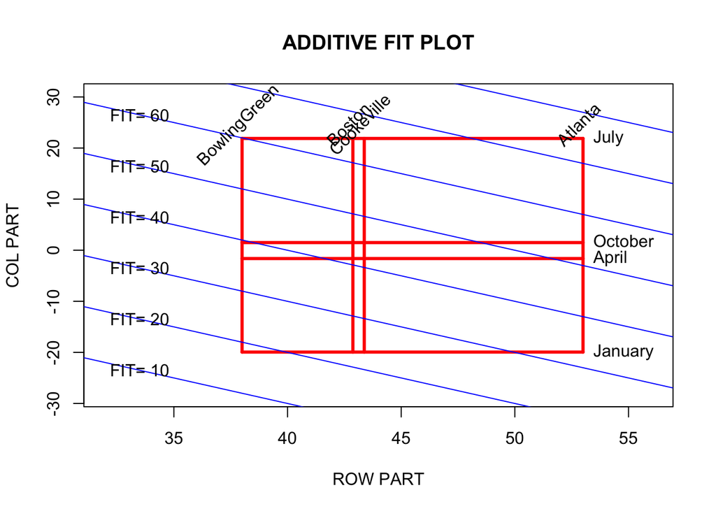

```r
Row.Part <- with(additive.fit, row + overall)
Col.Part <- additive.fit$col
plot2way(Row.Part, Col.Part,
         dimnames(temps)[[1]],
         dimnames(temps)[[2]])
```

First, note that the highest intersection corresponds to the temperature of Atlanta in July.(This results exactly the same as Dr Albert’s classnotes) According to the additive fit, Atlanta city in July is the most warmest place in this datasets. Conversely, Bowling Green in January is the coldest spot – this intersection has the smallest value of fit.

Second, Boston in October and Cookeville in April have similar values of fit. This is interesting because Boton and Cookevill (in TN) is not close to each other location wise.

Third, we can see that the rectangular region is just slightly rotated off the vertical so the more critical dimension of fit is the time of the year.

Looking at the residuals

```r
#Adding information about the residuals to the display
additive.fit$residual
```

```
##              January  April   July October
## BowlingGreen -3.0625 -0.375  2.125   0.500
## Atlanta       0.9375  0.625 -2.875  -0.500
## Boston       -0.9375 -0.250  0.250   2.625
## Cookeville    2.5625  0.250 -0.250  -0.875
```

```r
aplpack::stem.leaf(c(additive.fit$residual), unit=1, m=5)
```

```
## 1 | 2: represents 12
##  leaf unit: 1
##             n: 16
##         -1* |
##         -0. |
##           s |
##           f |
##    2      t | 32
##    8    -0* | 000000
##   (5)    0* | 00000
##    3      t | 222
##           f |
##           s |
##          0. |
##          1* |
```

Most of the residuals are small – between -1 and 1. The large residuals ane -3.0625 (Bowling Green, January) and 2.625 (Boston, October). Roughly, January has a large deviation between cities.

For multiplicative fits

```r
temps <- temperatures[, -1]
row.names(temps) <- temperatures[, 1]
temps
```

```
##              January April July October
## BowlingGreen      15    36   62      40
## Atlanta           34    52   72      54
## Boston            22    41   65      47
## Cookeville        26    42   65      44
```

What patterns do we see in this table? Actually, the temperatures increase January to July and after that they decrese. There is no relationship between the columns of the table is multiplicative, rather than additive. So in this case, a multiplicative model seems not to be suitable.

```r
#Fitting our model to the data
log.temps <- log10(temps)
log.temps
```

```
##               January    April     July  October
## BowlingGreen 1.176091 1.556303 1.792392 1.602060
## Atlanta      1.531479 1.716003 1.857332 1.732394
## Boston       1.342423 1.612784 1.812913 1.672098
## Cookeville   1.414973 1.623249 1.812913 1.643453
```

```r
additive.fit <- medpolish(log.temps)
```

```
## 1: 0.449655
## 2: 0.4314752
## Final: 0.4314752
```

```r
options(width=60)
additive.fit
```

```
##
## Median Polish Results (Dataset: "log.temps")
##
## Overall: 1.634877
##
## Row Effects:
## BowlingGreen      Atlanta       Boston   Cookeville
## -0.055696207  0.089321098 -0.002616358  0.002616358
##
## Column Effects:
##     January       April        July     October
## -0.25617944 -0.01686088  0.17803590  0.01553698
##
## Residuals:
##                January      April       July    October
## BowlingGreen -0.146911 -0.0060179  0.0351745  0.0073418
## Atlanta       0.063460  0.0086657 -0.0449020 -0.0073418
## Boston       -0.033659 -0.0026164  0.0026164  0.0242998
## Cookeville    0.033659  0.0026164 -0.0026164 -0.0095781
```

To demonstrate the fit, note that the log temperatures for Bowling Green in January is 1.176091 We can express this log temperatures as

1.176091 = 1.634877 - 0.055696207 - 0.25617944 - 0.146911

where

・ 1.634877 is the common value

・- 0.055696207 is the additive effect due to the Bowling green

・− 0.25617944 is the additive effect due to January

・− 0.146911 is the residual (what’s left of the data after taking out the additive fit)

To get a fit for the original temperature data, we take the common, row effects, column effects, and residuals each to the 10th power.

```r
COMMON <- 10 ^ additive.fit$overall
ROW <- 10 ^ additive.fit$row
COL <- 10 ^ additive.fit$col
RESIDUAL <- 10 ^ additive.fit$residual
COMMON
```

```
## [1] 43.13973
```

```r
ROW
```

```
## BowlingGreen      Atlanta       Boston   Cookeville
##    0.8796376    1.2283471    0.9939937    1.0060426
```

```r
COL
```

```
##   January     April      July   October
## 0.5543966 0.9619204 1.5067316 1.0364228
```

```r
RESIDUAL
```

```
##                January     April      July  October
## BowlingGreen 0.7129999 0.9862389 1.0843626 1.017049
## Atlanta      1.1573369 1.0201538 0.9017747 0.983237
## Boston       0.9254246 0.9939937 1.0060426 1.057547
## Cookeville   1.0805851 1.0060426 0.9939937 0.978187
```

Interpreting the fit

| *City Month* | January | April | July | October | REFF |
| --- | --- | --- | --- | --- | --- |
| Bowling Green |  |  |  |  | 0.8796376 |
| Atlanta |  |  |  |  | 1.2283471 |
| Boston |  |  |  |  | 0.9939937 |
| Cookeville |  |  |  |  | 1.0060426 |
| CEFF | 0.5543966 | 0.9619204 | 1.5067316 | 1.0364228 | 43.13973 |

To get fitted temperature for each month, we multiply the row effects (reff) by the common value to get the following table.

| *City Month* | January | April | July | October | RFIT | Additive RFIT |
| --- | --- | --- | --- | --- | --- | --- |
| Bowling Green |  |  |  |  | 37.94733 | (38) |
| Atlanta |  |  |  |  | 52.99056 | (53) |
| Boston |  |  |  |  | 42.88062 | (42.875) |
| Cookeville |  |  |  |  | 43.4004 | (43.375) |
| CEFF | 0.5543966 | 0.9619204 | 1.5067316 | 1.0364228 | 43.13973 | 43.125 |

To compare temperature in the cities, then we look at ratios. For example, comparing Bowling Green and Boston, the ratio of the corresponding row fits is 37.94733/42.88062 = 0.8849529. So we can say that temperature in Bowling Green were on the average about 11% (1-0.8849529) colder than Boston.

Likewise, we can see the effects of the different distances.

| *City Month* | January | April | July | October |
| --- | --- | --- | --- | --- |
| Column Effect | 0.5543966 | 0.9619204 | 1.5067316 | 1.0364228 |
| Effect / Effect (Jan) | 1 | 1.735076 | 2.717787 | 1.869461 |

From the table above, we can see that the July temperature is 2.717787 times as long as the January temperature. But the October temperature is 1.869461 times as long as the January temperature. So we can see the decrease from July to October.

To gain a better understanding of the row and column effects with plots.

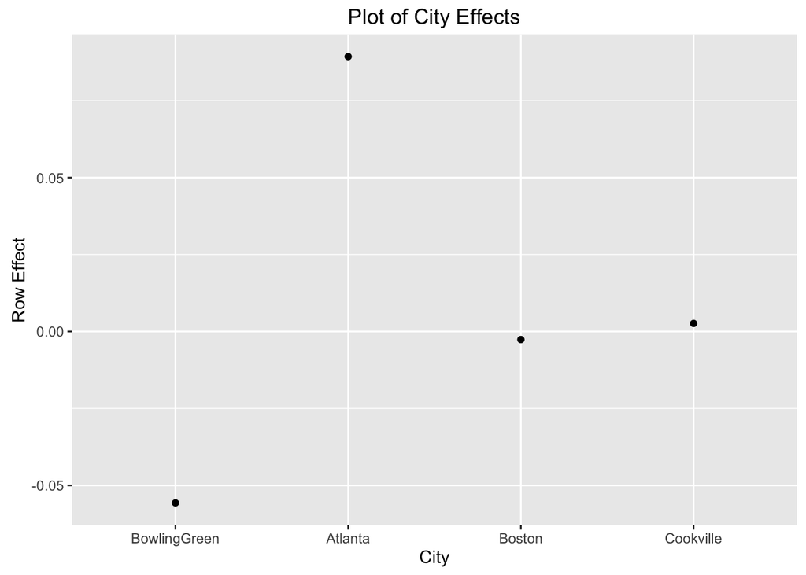

```r
#par(mfrow=c(2, 1))
#plot(city, additive.fit$row,
#     xlab="1=BowlingGreen, 2=Atlanta, 3=Boston, 4=Cookville",
#     ylab="Row Effect", pch=19,type="p",legend.text = NULL,
#main="Plot of Year Effects")
city <- c(1,2,3,4)
x <- factor(city, labels = c("BowlingGreen", "Atlanta", "Boston", "Cookville"))
require(ggplot2)
p <- qplot(x, additive.fit$row)+
  labs(title="Plot of City Effects",
       x="City", y = "Row Effect")
p
```

From this table above, we can see that Alanta has highest Row effect. Namely, the Atlant get warmer than any other cities in this datasets.

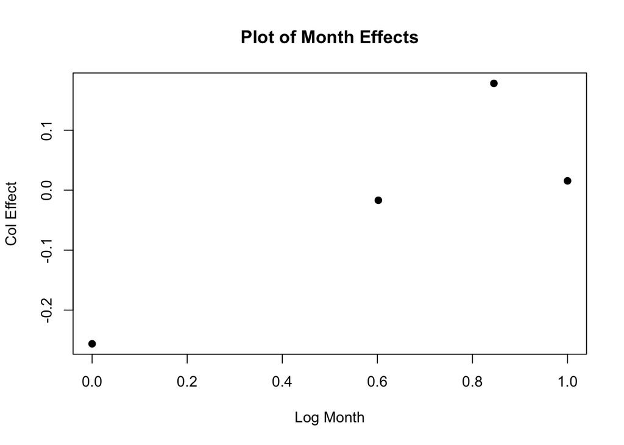

```r
month <- c(1,4,7,10)
month.1 <- log10(month)
plot(month.1, additive.fit$col,
     ylab="Col Effect", pch=19,type="p",
     xlab="Log Month",
     main="Plot of Month Effects")
```

We can see that Log month increase from 0.0 (January) to 0.8 (July) and decrese from 0.8 (July) to 1.0 (October).

Interpreting the residuals

```r
round(RESIDUAL, 2)
```

```
##              January April July October
## BowlingGreen    0.71  0.99 1.08    1.02
## Atlanta         1.16  1.02 0.90    0.98
## Boston          0.93  0.99 1.01    1.06
## Cookeville      1.08  1.01 0.99    0.98
```

The smallest residual is 0.71 (Bowling Green, January). The largest residual is 1.16 (Atlanta, January).

In conclusion, an additive fit is more suitable for your data to me since there is no multiplicative relationship between cities.

### 2.Fit a multiplicative fit to ONE of these two datasets:

I am going to choose the dataset,olympics.speed.skating.

olympics.speed.skating

This datasets give the Olympics winning time in the men’s speed skating as a function of the year and length of race.

For multiplicative fits

```r
head(olympics.speed.skating)
```

```
##   YEAR X500m X1000m X1500m X5000m X10000m
## 1 1976 39.17  79.32 119.38 444.48  890.59
## 2 1980 38.03  75.18 115.44 422.29  868.13
## 3 1984 38.19  75.80 118.36 432.28  879.90
## 4 1988 36.45  73.03 112.06 404.63  828.20
## 5 1992 37.14  74.85 114.81 419.97  852.12
## 6 1994 36.33  72.43 111.29 394.96  810.55
```

```r
times <- olympics.speed.skating[, -1]
row.names(times) <- olympics.speed.skating[, 1]
times
```

```
##      X500m X1000m X1500m X5000m X10000m
## 1976 39.17  79.32 119.38 444.48  890.59
## 1980 38.03  75.18 115.44 422.29  868.13
## 1984 38.19  75.80 118.36 432.28  879.90
## 1988 36.45  73.03 112.06 404.63  828.20
## 1992 37.14  74.85 114.81 419.97  852.12
## 1994 36.33  72.43 111.29 394.96  810.55
## 1998 35.59  70.64 107.87 382.20  795.33
## 2002 34.42  67.18 103.95 374.66  778.92
## 2006 34.82  68.89 105.97 374.68  781.57
```

What patterns do we see in this table?

Certainly, we can see the times to get larger for the longer distances. Also, we see some decrease in the winning times as a function of year. There are improvements in training and skating technique that can lead to better race times.

So, in this case, An multiplicative model is more suitable.

```r
#Fitting our model to the data
log.times <- log10(times)
log.times
```

```
##         X500m   X1000m   X1500m   X5000m  X10000m
## 1976 1.592954 1.899383 2.076932 2.647852 2.949678
## 1980 1.580126 1.876102 2.062356 2.625611 2.938585
## 1984 1.581950 1.879669 2.073205 2.635765 2.944433
## 1988 1.561698 1.863501 2.049451 2.607058 2.918135
## 1992 1.569842 1.874192 2.059980 2.623218 2.930501
## 1994 1.560265 1.859918 2.046456 2.596553 2.908780
## 1998 1.551328 1.849051 2.032901 2.582291 2.900547
## 2002 1.536811 1.827240 2.016824 2.573637 2.891493
## 2006 1.541829 1.838156 2.025183 2.573661 2.892968
```

```r
additive.fit <- medpolish(log.times)
```

```
## 1: 0.135343
## 2: 0.1275123
## Final: 0.1272076
```

```r
options(width=60)
additive.fit
```

```
##
## Median Polish Results (Dataset: "log.times")
##
## Overall: 2.049451
##
## Row Effects:
##         1976         1980         1984         1988
##  0.029706154  0.014653710  0.023754338  0.000000000
##         1992         1994         1998         2002
##  0.010529099 -0.005207217 -0.016549939 -0.032626124
##         2006
## -0.025345116
##
## Column Effects:
##      X500m     X1000m     X1500m     X5000m    X10000m
## -0.4839780 -0.1859493  0.0000000  0.5576075  0.8705210
##
## Residuals:
##           X500m      X1000m     X1500m      X5000m
## 1976 -0.0022252  0.00617525 -0.0022252  0.01108799
## 1980  0.0000000 -0.00205269 -0.0017480  0.00389901
## 1984 -0.0072773 -0.00758643  0.0000000  0.00495273
## 1988 -0.0037751  0.00000000  0.0000000  0.00000000
## 1992 -0.0061598  0.00016141  0.0000000  0.00563109
## 1994  0.0000000  0.00162440  0.0022127 -0.00529775
## 1998  0.0024053  0.00209933  0.0000000 -0.00821746
## 2002  0.0039644 -0.00363518  0.0000000 -0.00079463
## 2006  0.0017013  0.00000000  0.0010774 -0.00805245
##          X10000m
## 1976  0.00000000
## 1980  0.00395939
## 1984  0.00070732
## 1988 -0.00183643
## 1992  0.00000000
## 1994 -0.00598463
## 1998 -0.00287436
## 2002  0.00414732
## 2006 -0.00165866
```

To demonstrate the fit, note that the log time for the 500 m race in 1976 is 1.592954.

We can express this log temperatures as

1.592954 = 2.049451 + 0.029706154 - 0.4839780 - 0.0022252

where

・ 2.049451 is the common value

・− 0.0022252 is the residual (what’s left of the data after taking out the additive fit)

To get a fit for the original time data, we take the common, row effects, column effects, and residuals each to the 10th power.

```r
COMMON <- 10 ^ additive.fit$overall
ROW <- 10 ^ additive.fit$row
COL <- 10 ^ additive.fit$col
RESIDUAL <- 10 ^ additive.fit$residual
COMMON
```

```
## [1] 112.06
```

```r
ROW
```

```
##      1976      1980      1984      1988      1992      1994
## 1.0707946 1.0343171 1.0562199 1.0000000 1.0245404 0.9880815
##      1998      2002      2006
## 0.9626093 0.9276281 0.9433110
```

```r
COL
```

```
##     X500m    X1000m    X1500m    X5000m   X10000m
## 0.3281119 0.6517044 1.0000000 3.6108335 7.4220016
```

```r
RESIDUAL
```

```
##          X500m    X1000m    X1500m    X5000m   X10000m
## 1976 0.9948894 1.0143206 0.9948894 1.0258598 1.0000000
## 1980 1.0000000 0.9952847 0.9959831 1.0090182 1.0091585
## 1984 0.9833830 0.9826833 1.0000000 1.0114693 1.0016300
## 1988 0.9913452 1.0000000 1.0000000 1.0000000 0.9957804
## 1992 0.9859166 1.0003717 1.0000000 1.0130505 1.0000000
## 1994 1.0000000 1.0037473 1.0051080 0.9878756 0.9863144
## 1998 1.0055538 1.0048456 1.0000000 0.9812565 0.9934034
## 2002 1.0091701 0.9916646 1.0000000 0.9981720 1.0095953
## 2006 1.0039250 1.0000000 1.0024840 0.9816294 0.9961881
```

Interpreting the fit

| *year meter* | 500m | 1000m | 1500m | 5000m | 10000m | REFF |
| --- | --- | --- | --- | --- | --- | --- |
| 1976 |  |  |  |  |  | 1.0707946 |
| 1980 |  |  |  |  |  | 1.0343171 |
| 1984 |  |  |  |  |  | 1.0562199 |
| 1988 |  |  |  |  |  | 1.0000000 |
| 1992 |  |  |  |  |  | 1.0245404 |
| 1994 |  |  |  |  |  | 0.9880815 |
| 1998 |  |  |  |  |  | 0.9626093 |
| 2002 |  |  |  |  |  | 0.9276281 |
| 2006 |  |  |  |  |  | 0.9433110 |
| CEFF | 0.3281119 | 0.6517044 | 1.0000000 | 3.6108335 | 7.4220016 | 112.06 |

To get fitted time for each year, we multiply the row effects (reff) by the common value to get the following table.

| *year meter* | 500m | 1000m | 1500m | 5000m | 10000m | RFIT |
| --- | --- | --- | --- | --- | --- | --- |
| 1976 |  |  |  |  |  | 119.9932 |
| 1980 |  |  |  |  |  | 115.9056 |
| 1984 |  |  |  |  |  | 118.36 |
| 1988 |  |  |  |  |  | 112.06 |
| 1992 |  |  |  |  |  | 114.81 |
| 1994 |  |  |  |  |  | 110.7244 |
| 1998 |  |  |  |  |  | 107.87 |
| 2002 |  |  |  |  |  | 103.95 |
| 2006 |  |  |  |  |  | 105.7074 |
| CEFF | 0.3281119 | 0.6517044 | 1.0000000 | 3.6108335 | 7.4220016 |  |

To compare years, then we look at ratios. For example, comparing 1976 and 2006, the ratio of the corresponding row fits is 119.9932/105.7074 = 1.135145. So we can say that times in 1976 were on the average about 14% slower than they were in the year 2006.

Likewise, we can see the effects of the different distances.

| *meter* | 500m | 1000m | 1500m | 5000m | 10000m |
| --- | --- | --- | --- | --- | --- |
| Column Effect | 0.3281119 | 0.6517044 | 1.0000000 | 3.6108335 | 7.4220016 |
| Effect / Effect (500m) | 1 | 1.986226 | 3.047741 | 11.00488 | 22.62034 |

The 1000m time is barely twice as long as the 500m. The 1500m time is barely third time as long as the 500m. However, the 10000m time is 22.6 times as long as the 500m time. So we can slightly see a fatigue effect.

To gain a better understanding of the row and column effects with plots.

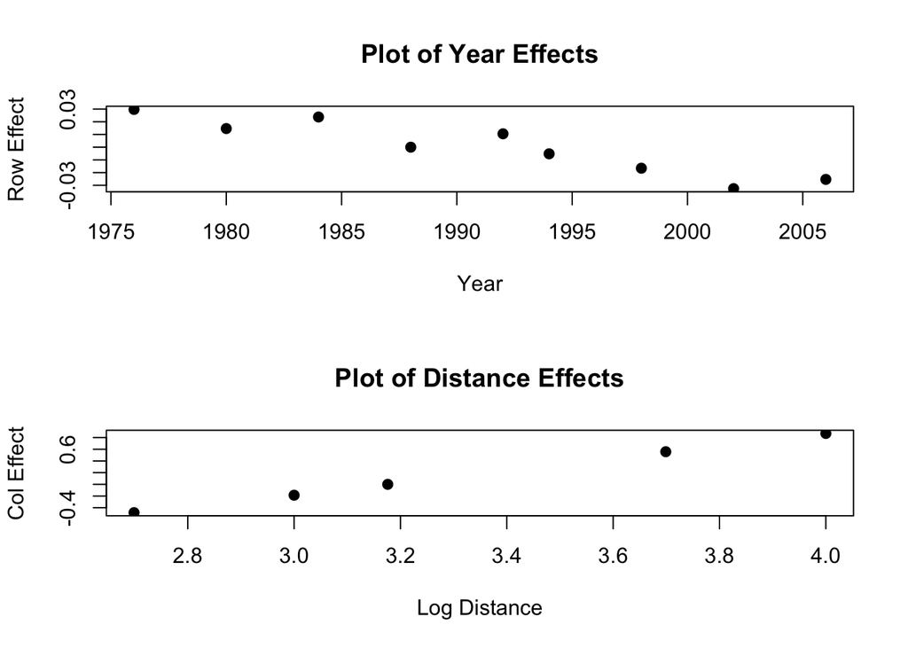

```r
Year <- c(1976, 1980, 1984, 1988, 1992, 1994, 1998, 2002, 2006)
Log.Distance <- log10(c(500, 1000, 1500, 5000, 10000))
par(mfrow=c(2, 1))
plot(Year, additive.fit$row,
     ylab="Row Effect", pch=19,
main="Plot of Year Effects")

plot(Log.Distance, additive.fit$col,
     ylab="Col Effect", pch=19,
     xlab="Log Distance",
     main="Plot of Distance Effects")
```

From the graphs, we see

・There was general decrease in log time from 1976 to 2005 but 1984, 1992 and 2006 increased a little bit from previous year.

・Year 2002 has the short times in this datasets.

・The log times increase linearly as a function of log distance. However,this graph doesn’t show the fatigue effect.

Interpreting the residuals

```r
round(RESIDUAL, 2)
```

```
##      X500m X1000m X1500m X5000m X10000m
## 1976  0.99   1.01   0.99   1.03    1.00
## 1980  1.00   1.00   1.00   1.01    1.01
## 1984  0.98   0.98   1.00   1.01    1.00
## 1988  0.99   1.00   1.00   1.00    1.00
## 1992  0.99   1.00   1.00   1.01    1.00
## 1994  1.00   1.00   1.01   0.99    0.99
## 1998  1.01   1.00   1.00   0.98    0.99
## 2002  1.01   0.99   1.00   1.00    1.01
## 2006  1.00   1.00   1.00   0.98    1.00
```

Generally, the residuals are between 0.98 and 1.01. There is the largest residual in 5000m in year 1976.

### 3.For the following data, analyze using an extended fit. Interpret the fit and the residuals.

Response: average (median) attendance of worship at Norcrest church,Findlay,OH classified by month and year. Dataset: church.2way

```r
attendance <- church.2way[, -1]
row.names(attendance) <- church.2way[, 1]
attendance
```

```
##      y1993 y1994 y1995 y1996
## Jan    336   335   394   381
## Feb    295   369   358   385
## Mar    308   395   364   418
## Apr    321   420   388   413
## May    323   399   379   393
## June   305   355   343   375
## July   265   310   309   338
## Aug    301   301   344   335
## Sept   288   338   399   429
## Oct    345   349   402   399
## Nov    405   376   398   424
## Dec    378   386   401   381
```

To show the an additive model using median polish.

```r
(additive.fit <- medpolish(attendance))
```

```
## 1: 786
## 2: 739.25
## Final: 735
```

```
##
## Median Polish Results (Dataset: "attendance")
##
## Overall: 370.5156
##
## Row Effects:
##        Jan        Feb        Mar        Apr        May
##  -2.203125 -12.484375   7.015625  16.515625   2.015625
##       June       July        Aug       Sept        Oct
## -20.703125 -59.734375 -44.484375  -2.015625  11.296875
##        Nov        Dec
##  27.015625  22.984375
##
## Column Effects:
##      y1993      y1994      y1995      y1996
## -45.296875  -4.140625   3.718750  25.578125
##
## Residuals:
##          y1993    y1994    y1995     y1996
## Jan   12.98438 -29.1719  21.9688 -12.89062
## Feb  -17.73438  15.1094  -3.7500   1.39062
## Mar  -24.23438  21.6094 -17.2500  14.89062
## Apr  -20.73438  37.1094  -2.7500   0.39062
## May   -4.23438  30.6094   2.7500  -5.10938
## June   0.48438   9.3281 -10.5312  -0.39062
## July  -0.48438   3.3594  -5.5000   1.64062
## Aug   20.26562 -20.8906  14.2500 -16.60938
## Sept -35.20312 -26.3594  26.7812  34.92188
## Oct    8.48438 -28.6719  16.4688  -8.39062
## Nov   52.76562 -17.3906  -3.2500   0.89062
## Dec   29.79688  -3.3594   3.7812 -38.07812
```

From this table above, it will be helpful to order the rows and columns of the table by the effects. Actually, the columns are already ordered by effects, however, the row are not.

```r
attendance <- attendance[order(additive.fit$row), ]
(additive.fit <- medpolish(attendance))
```

```
## 1: 786
## 2: 739.25
## Final: 735
```

```
##
## Median Polish Results (Dataset: "attendance")
##
## Overall: 370.5156
##
## Row Effects:
##       July        Aug       June        Feb        Jan
## -59.734375 -44.484375 -20.703125 -12.484375  -2.203125
##       Sept        May        Mar        Oct        Apr
##  -2.015625   2.015625   7.015625  11.296875  16.515625
##        Dec        Nov
##  22.984375  27.015625
##
## Column Effects:
##      y1993      y1994      y1995      y1996
## -45.296875  -4.140625   3.718750  25.578125
##
## Residuals:
##          y1993    y1994    y1995     y1996
## July  -0.48438   3.3594  -5.5000   1.64062
## Aug   20.26562 -20.8906  14.2500 -16.60938
## June   0.48438   9.3281 -10.5312  -0.39062
## Feb  -17.73438  15.1094  -3.7500   1.39062
## Jan   12.98438 -29.1719  21.9688 -12.89062
## Sept -35.20312 -26.3594  26.7812  34.92188
## May   -4.23438  30.6094   2.7500  -5.10938
## Mar  -24.23438  21.6094 -17.2500  14.89062
## Oct    8.48438 -28.6719  16.4688  -8.39062
## Apr  -20.73438  37.1094  -2.7500   0.39062
## Dec   29.79688  -3.3594   3.7812 -38.07812
## Nov   52.76562 -17.3906  -3.2500   0.89062
```

Now both row and column effects are ordered.

Interpret the fit. From Row Effects, there was the lowest attendance in July (370.5156 - 59.734375 = 310.7812) and there was the highest attendance in November (370.5156 + 27.015625 = 397.5312).

From Column Effects, we can see that attendance was incresing every year. The lowest attendance is 325.2187 in year 1993 and the highest one is 396.0937 in year 1996.

Looking at residuals

```r
additive.fit$residual
```

```
##           y1993      y1994     y1995      y1996
## July  -0.484375   3.359375  -5.50000   1.640625
## Aug   20.265625 -20.890625  14.25000 -16.609375
## June   0.484375   9.328125 -10.53125  -0.390625
## Feb  -17.734375  15.109375  -3.75000   1.390625
## Jan   12.984375 -29.171875  21.96875 -12.890625
## Sept -35.203125 -26.359375  26.78125  34.921875
## May   -4.234375  30.609375   2.75000  -5.109375
## Mar  -24.234375  21.609375 -17.25000  14.890625
## Oct    8.484375 -28.671875  16.46875  -8.390625
## Apr  -20.734375  37.109375  -2.75000   0.390625
## Dec   29.796875  -3.359375   3.78125 -38.078125
## Nov   52.765625 -17.390625  -3.25000   0.890625
```

| table | y1993 | y1994 | y1995 | y1996 | REFF | sign |
| --- | --- | --- | --- | --- | --- | --- |
| July | -0.484375 | 3.359375 | -5.50000 | 1.640625 | -59.734375 | *-* |
| Aug | 20.265625 | -20.890625 | 14.25000 | -16.609375 | -44.484375 | *-* |
| June | 0.484375 | 9.328125 | -10.53125 | -0.390625 | -20.703125 | *-* |
| Feb | -17.734375 | 15.109375 | -3.75000 | 1.390625 | -12.484375 | *-* |
| Jan | 12.984375 | -29.171875 | 21.96875 | -12.890625 | -2.203125 | *-* |
| Sept | -35.203125 | -26.359375 | 26.78125 | 34.921875 | -2.015625 | *-* |
| May | -4.234375 | 30.609375 | 2.75000 | -5.109375 | 2.015625 | *+* |
| Mar | -24.234375 | 21.609375 | -17.25000 | 14.890625 | 7.015625 | *+* |
| Oct | 8.484375 | -28.671875 | 16.46875 | -8.390625 | 11.296875 | *+* |
| Apr | -20.734375 | 37.109375 | -2.75000 | 0.390625 | 16.515625 | *+* |
| Dec | 29.796875 | -3.359375 | 3.78125 | -38.078125 | 22.984375 | *+* |
| Nov | 52.765625 | -17.390625 | -3.25000 | 0.890625 | 27.015625 | *+* |
| CEFF | -45.296875 | -4.140625 | 3.718750 | 25.578125 |  |  |
| sign | *-* | *-* | *+* | *+* |  |  |

There is large residual which is 52.765625 (Nov,y1993). The smallest residual is -38.078125 (Dec,y1996).

Both results are interesting because the column effects in year 1993 is the lowest but there is the largest deviation in residual in year 1993. On the other hand, year 1996 has the largest column effects (25.578125), however the lowest residual (-38.078125) is in year 1996.

Comparison values

$cv = ROWEFF × COLEFF / COMMON$

Extending the additive model by one more term

This new model callesd extended model.

$FIT = COMMON +ROW EFF +COLEFF +kCV$

Finding k

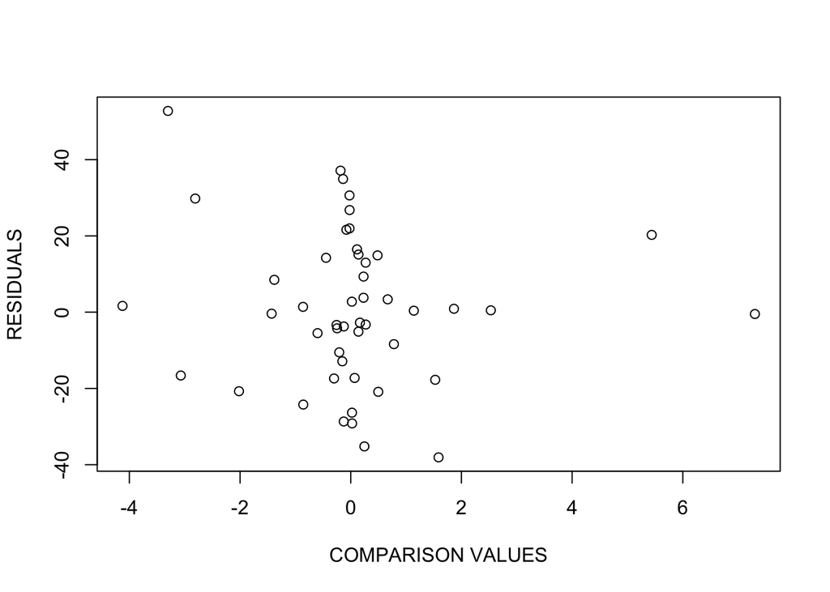

```r
cv <- with(additive.fit,
           outer(row, col, "*") / overall)
plot(as.vector(cv), as.vector(additive.fit$residuals),
    xlab = "COMPARISON VALUES", ylab = "RESIDUALS")
```

```r
rline(as.vector(cv), as.vector(additive.fit$residuals))$b
```

```
## [1] 1.460397
```

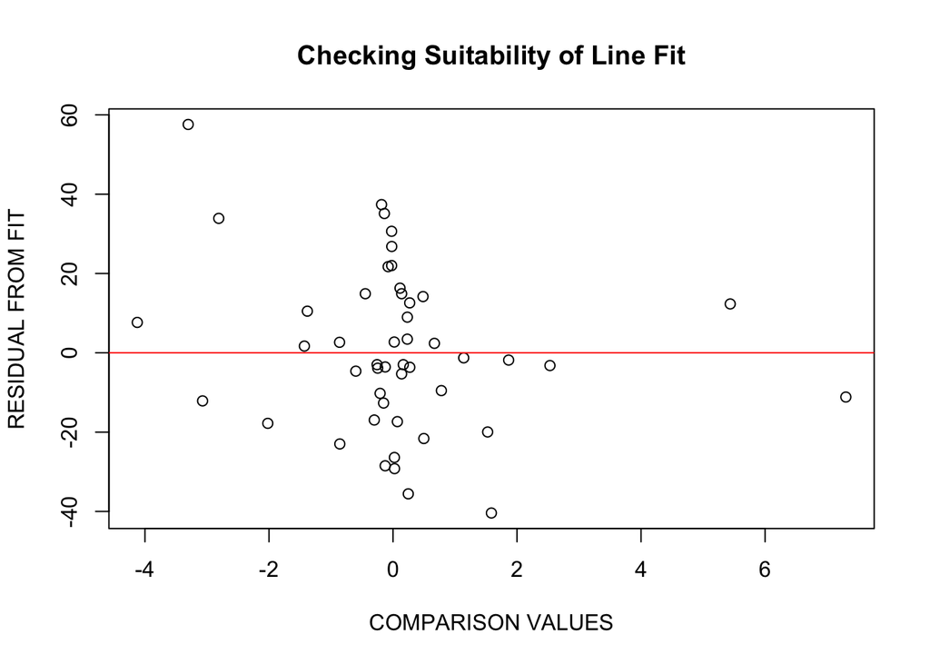

```r
# We check the suitability of our line fit by looking at the residuals and seeing if we have removed the trend from the scatterplot. (It appears from the graph that we have indeed removed the trend from the plot.)

plot(as.vector(cv),
as.vector(additive.fit$residuals) - 1.460397* as.vector(cv), xlab = "COMPARISON VALUES", ylab = "RESIDUAL FROM FIT", main="Checking Suitability of Line Fit")
abline(h=0, col="red")
```

The slope of this line, 1.460397, is our estimate at the coefficient k. So our improved fit to these data has the form

$FIT = COMMON +ROW EFF +COLEFF +1.460397CV$

If k is not close to 1, then the recommendation is to perform an additive fit to transformed data where the data is reexpressed using a power transformation with power p = 1 − k. Therefore p = 1 - 1.460397 = -0.460397

Extended fits and transformations

```r
attendance <- church.2way[, -1]
attendance <- attendance^(-0.46)
dimnames(attendance)[[1]] <- church.2way[, 1]
additive.fit <- medpolish(attendance)
```

```
## 1: 0.06863879
## 2: 0.06363241
## Final: 0.06350827
```

```r
medpolish(attendance)
```

```
## 1: 0.06863879
## 2: 0.06363241
## Final: 0.06350827
```

```
##
## Median Polish Results (Dataset: "attendance")
##
## Overall: 0.06542966
##
## Row Effects:
##           Jan           Feb           Mar           Apr
##  9.175352e-05  1.349652e-03 -1.053228e-04 -8.928534e-04
##           May          June          July           Aug
## -9.175352e-05  1.897287e-03  6.068761e-03  4.105569e-03
##          Sept           Oct           Nov           Dec
##  7.068846e-04 -9.133416e-04 -1.644051e-03 -1.400416e-03
##
## Column Effects:
##         y1993         y1994         y1995         y1996
##  0.0047123570  0.0002541476 -0.0001503402 -0.0018977819
##
## Residuals:
##            y1993       y1994       y1995       y1996
## Jan  -1.3869e-03  0.00316572 -1.3870e-03  1.3556e-03
## Feb   1.6024e-03 -0.00109059  2.3833e-04 -2.1374e-04
## Mar   1.6216e-03 -0.00166900  1.1840e-03 -1.1594e-03
## Apr   1.0593e-03 -0.00266039  5.0839e-05 -2.6251e-05
## May   5.7613e-05 -0.00197809 -5.0839e-05  6.1876e-04
## June -5.7613e-05 -0.00045445  1.0203e-03  2.6251e-05
## July  5.7961e-04 -0.00030728  2.0347e-04 -9.4151e-04
## Aug  -1.8274e-03  0.00263077 -1.2792e-03  1.3038e-03
## Sept  3.0571e-03  0.00226844 -2.3722e-03 -2.7112e-03
## Oct  -1.2139e-03  0.00288459 -9.7084e-04  9.9542e-04
## Nov  -5.3193e-03  0.00133552  5.2165e-05 -2.7577e-05
## Dec  -3.5257e-03  0.00030728 -4.1109e-04  2.8478e-03
```

Interpret the fit. From Row Effects, the $attendance^{(-0.46)}$ in July is 0.07149842 (0.06542966 + 6.068761e-03).

The $attendance^{(-0.46)}$ in November 0.06378561 (0.06542966-1.644051e-03).

From Column Effects, y1993, y1994 ,y1995 and y1996 are (0.0047123570, 0.0002541476, -0.0001503402, -0.0018977819) respectively.

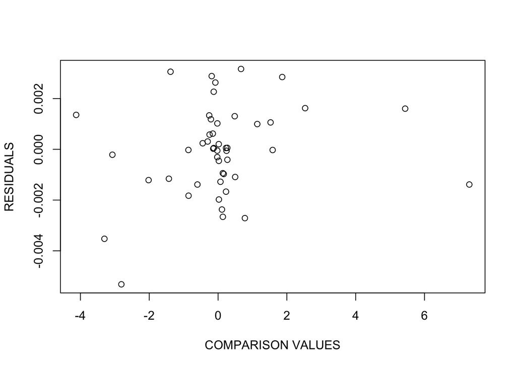

```r
plot(as.vector(cv), as.vector(additive.fit$residuals),
    xlab = "COMPARISON VALUES", ylab = "RESIDUALS")
```

The residuals are transformed within smaller range.

Plotting the two terms of the additive fit

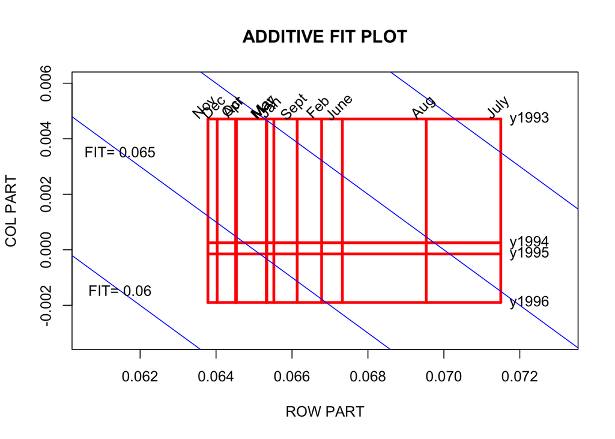

```r
Row.Part <- with(additive.fit, row + overall)
Col.Part <- additive.fit$col
plot2way(Row.Part, Col.Part,
         dimnames(attendance)[[1]],
         dimnames(attendance)[[2]])
```

Second, there are larger two red rectangulars between June and July.

Third, we can see that the rectangular region is just slightly rotated off the vertical so the more critical dimension of fit is the month of the year.

Checking stemplot for residuals

```r
aplpack::stem.leaf(c(additive.fit$residual))
```

```
## 1 | 2: represents 0.0012
##  leaf unit: 1e-04
##             n: 48
## LO: -0.0053192703384041
##    2    -3. | 5
##         -3* |
##    4    -2. | 76
##    5    -2* | 3
##    8    -1. | 986
##   14    -1* | 332210
##   16    -0. | 99
##   24    -0* | 44320000
##   (7)    0* | 0000223
##   17     0. | 569
##   14     1* | 001333
##    8     1. | 66
##    6     2* | 2
##    5     2. | 688
##    2     3* | 01
```

There is a cluster between -0.0004 and 0.0003.

There is one lower deviasion which is 0.0053192703384041 which is in November in 1993.